# Differential expression and geneset enrichment analysis

Computational Biology group

2023-07-27

The following material has been adapted from the 2023 Swiss Institute of Bioinformatics single cell RNA sequencing course (https://sib-swiss.github.io/single-cell-training/) authored by Tania Wyss, Rachel Marcone-Jeitziner, Geert van Geest, and Patricia Palagi

```r
library(Seurat)
library(ggplot2)
library(dplyr)
library(DESeq2)
library(org.Hs.eg.db)
library(clusterProfiler)
library(enrichplot)
```

### Load the Seurat object that has cell assignment

```r
load("seu_clusters_integrated_cell_assign.RData")
```

# Differential expression analysis - single cell level

The primary function for differential expression in Seurat is FindMarkers (not FindAllMarkers). Before you run it you need to set the identifiers of the Seurat object to the metadata variable you want to use for differential expression. Here we are going to use the annotation from SingleR. Some of the key arguments for the FindMarkers function are logfc.threshold, min.pct, min.cells.feature, test.use. By default, FindMarkers uses a fold change threshold of 0.25 rather than p-value and uses the Wilcoxon test (test.use).

```r
seu <- Seurat::SetIdent(seu, value = "SingleR_annot")
Idents(seu) <- "SingleR_annot"

# Before we run FindMarkers, let's look at the function using ?FindMarkers
# Run differential expression between T cell subtypes
deg_cd8_cd4 <- Seurat::FindMarkers(seu,
                                   ident.1 = "CD8+ T cells",
                                   ident.2 = "CD4+ T cells",
                                   group.by = seu$SingleR_annot,
                                   test.use = "wilcox")
```

### Inspecting the output of differential expression

As mentioned above, FindMarkers uses a fold change rather than a p-value threshold so often we want to remove the genes that did not meet the adjusted p-value.

```r
# Optionally remove the DEGs that did not meet the adjusted p-value
deg_cd8_cd4 <- subset(deg_cd8_cd4, deg_cd8_cd4$p_val_adj<0.05)
```

##### You can look for particular genes of interest as shown below.

ident.1 from FindMarkers above corresponds to pct.1 in the output while ident.2 corresponds to pct.2 in the output. A positive fold change means up in ident.1 (CD8+ T cells here) while a negative fold change means down in ident.1. Let’s look at CD4 and CD8 genes to see if the results make sense.

```r
deg_cd8_cd4[c("CD4", "CD8A", "CD8B"),]
```

```
##             p_val avg_log2FC pct.1 pct.2    p_val_adj
## CD4  2.290800e-14 -0.4085478 0.011 0.105 4.277611e-10
## CD8A 2.889582e-74  1.2738951 0.336 0.008 5.395717e-70
## CD8B 3.756143e-34  0.8521656 0.470 0.178 7.013846e-30
```

As you would expect (if your cell annotation is correct), CD8A and CD8B have a positive fold change showing that they are higher in CD8+ T cells. CD4 has a negative fold change meaning that it is lower in CD8 T cells than in CD8 T cells. If genes are in the opposite direction or the DEG list does not contain at least some of the genes that you would expect, you may need to redo your cell annotation.

#### Checking genes of interest with a plot instead of printing a table

An alternative approach is to use violin plots. Here, we are using the idents argument to only look at two of the groups from the singleR_annot column (our current active.ident) rather than plotting them all.

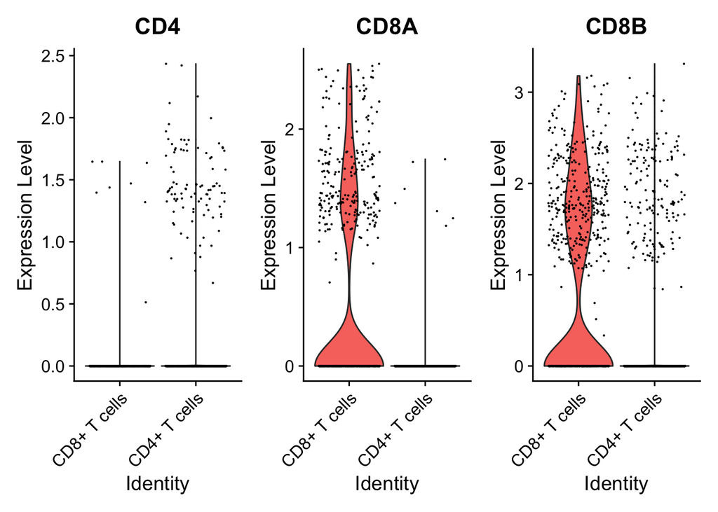

```r
Seurat::VlnPlot(seu,
                features = c("CD4", "CD8A", "CD8B"),
                idents = c("CD8+ T cells", "CD4+ T cells"))
```

#### Summary

Superficially, it seems like SingleR has done a reasonable job separating between CD8 and CD4 T cells. Now let’s summarise the genes using geneset enrichment analysis.

## Geneset enrichment analysis

The point of geneset enrichment analysis is to summarise your list of differentially expressed genes, as often you will have hundreds or sometimes thousands. Geneset enrichment uses databases of known gene functions and groups/pathways with popular ones including gene ontology (GO), Reactome, KEGG, and MSigDb. The statistical basis of enrichment analysis is asking if there are more genes from these known gene groups/pathways than what we would expect. For example, if we chose 100 genes at random, how many genes would we expect there to be from the “immune response” Gene Ontology term.

```r
# install packages if necessary
# BiocManager::install(c("org.Hs.eg.db","clusterProfiler","enrichplot"))
library(org.Hs.eg.db)
library(clusterProfiler)
library(enrichplot)
```

### Run enrichment analysis using clusterProfiler

As always, look at the arguments of the function before you use it with ?enrichGO. Keytype specifies whether you are using gene symbol, ensembl ID, entrezgene etc, minGSSize sets the minimum size of the GO results - GO terms start from very broad terms (eg biological process) and get progressively smaller and more specific. You can also alter maxGSSize (default value is 500) to remove the large vague ones. These default maximum and minimum values vary considerably depending on the enrichment method that you are using. If you are running more than one then keep the parameters the same.

```r
# Set up annotation
AnnotationDbi::keytypes(org.Hs.eg.db)
```

```
##  [1] "ACCNUM"       "ALIAS"        "ENSEMBL"      "ENSEMBLPROT"  "ENSEMBLTRANS"
##  [6] "ENTREZID"     "ENZYME"       "EVIDENCE"     "EVIDENCEALL"  "GENENAME"
## [11] "GENETYPE"     "GO"           "GOALL"        "IPI"          "MAP"
## [16] "OMIM"         "ONTOLOGY"     "ONTOLOGYALL"  "PATH"         "PFAM"
## [21] "PMID"         "PROSITE"      "REFSEQ"       "SYMBOL"       "UCSCKG"
## [26] "UNIPROT"
```

```r
# Run clusterProfiler
cd8_vs_cd4_go <- clusterProfiler::enrichGO(rownames(deg_cd8_cd4),
                                            "org.Hs.eg.db",
                                            keyType = "SYMBOL",
                                            ont = "BP",
                                            minGSSize = 50)
# Get a dataframe of the results and look at the top results using head()
cd8_vs_cd4_df <- data.frame(cd8_vs_cd4_go)
head(cd8_vs_cd4_df)
```

```
##                    ID
## GO:0050852 GO:0050852
## GO:0002429 GO:0002429
## GO:0002757 GO:0002757
## GO:0050851 GO:0050851
## GO:0002768 GO:0002768
## GO:0002253 GO:0002253
##                                                                   Description
## GO:0050852                                  T cell receptor signaling pathway
## GO:0002429 immune response-activating cell surface receptor signaling pathway
## GO:0002757                     immune response-activating signal transduction
## GO:0050851                        antigen receptor-mediated signaling pathway
## GO:0002768 immune response-regulating cell surface receptor signaling pathway
## GO:0002253                                      activation of immune response
##            GeneRatio   BgRatio       pvalue     p.adjust       qvalue
## GO:0050852     10/55 139/18903 7.351726e-12 7.660498e-09 5.827210e-09
## GO:0002429     11/55 312/18903 1.302657e-09 4.524563e-07 3.441758e-07
## GO:0002757     11/55 312/18903 1.302657e-09 4.524563e-07 3.441758e-07
## GO:0050851     10/55 252/18903 2.562419e-09 6.675102e-07 5.077636e-07
## GO:0002768     11/55 341/18903 3.302799e-09 6.883032e-07 5.235805e-07
## GO:0002253     11/55 397/18903 1.594987e-08 2.769961e-06 2.107062e-06
##                                                                     geneID
## GO:0050852       CD8A/CD8B/TRGC2/TRGC1/TRDC/CBLB/TRAT1/HLA-DPB1/CCR7/HLA-A
## GO:0002429 CD8A/CD8B/TRGC2/KLRD1/TRGC1/TRDC/CBLB/TRAT1/HLA-DPB1/CCR7/HLA-A
## GO:0002757 CD8A/CD8B/TRGC2/KLRD1/TRGC1/TRDC/CBLB/TRAT1/HLA-DPB1/CCR7/HLA-A
## GO:0050851       CD8A/CD8B/TRGC2/TRGC1/TRDC/CBLB/TRAT1/HLA-DPB1/CCR7/HLA-A
## GO:0002768 CD8A/CD8B/TRGC2/KLRD1/TRGC1/TRDC/CBLB/TRAT1/HLA-DPB1/CCR7/HLA-A
## GO:0002253 CD8A/CD8B/TRGC2/KLRD1/TRGC1/TRDC/CBLB/TRAT1/HLA-DPB1/CCR7/HLA-A
##            Count
## GO:0050852    10
## GO:0002429    11
## GO:0002757    11
## GO:0050851    10
## GO:0002768    11
## GO:0002253    11
```

### Removing Gene ontology redundancy

Gene ontologies have a tree-based structure, so results can often include multiple very similar terms. This is referred to as redundancy. clusterProfiler has a function called simplify that removes terms based on a user-defined threshold (“cutoff” argument).

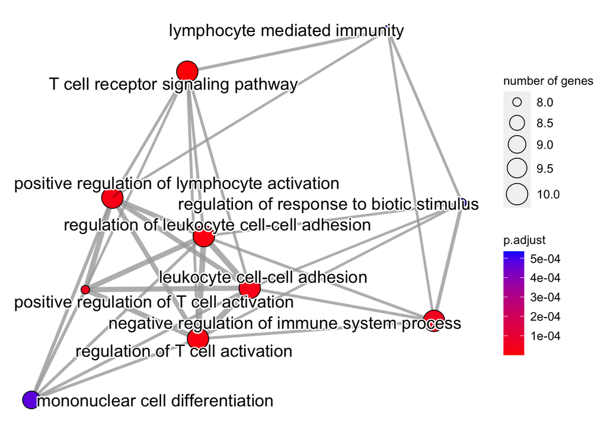

```r
# Try and remove some of the redundancy in the results
enr_go <- clusterProfiler::simplify(cd8_vs_cd4_go,cutoff=0.7)

# Make a graph using emap plot - connections on the plot reflect
# the similarity between the terms. change showCategory to show more/less terms
enrichplot::emapplot(enrichplot::pairwise_termsim(enr_go),
                     showCategory = 10)
```

### Note on geneset enrichment analysis

There are web-based platforms that you can use for enrichment analysis as well. These can be helpful if you have found a gene list from somewhere such as a publication. I have previously used WebGestalt and StringDB (links below). https://www.webgestalt.org/ and https://string-db.org/ (go to search on StringDB and then select multiple proteins, paste your gene list into the box). The two websites have different default settings for minimum/maximum gene set sizes and are updated at different times so results will tend to be similar but not identical.

### Save outputs

No need to save our Seurat object as we haven’t added anything to it this time. You can save your differential expression and enrichment results. It can be a good idea to save them both as a csv and RData file if you are planning on opening the results in Excel.

```r
# Save csv files
write.csv(deg_cd8_cd4,file="deg_cd8_cd4_findmarkers.csv")
write.csv(cd8_vs_cd4_df,file="deg_cd8_cd4_enrichGO.csv")

# Save RData files
save(deg_cd8_cd4,file="deg_cd8_cd4_findmarkers.RData")
save(cd8_vs_cd4_df,file="deg_cd8_cd4_enrichGO.RData")
```

# Pseudobulk analysis

In a pseudobulk analysis the counts for each gene are aggregated across cells to get a single count value per sample for each gene (the same format as if you were doing a bulk RNA-seq experiment). Typically aggregation is done across cells belonging to a particular cell type, and seperate differential expression analyses are run for each cell type. Pseudobulk analysis can produce more reliable results but does require that you have replicates for each group. We have only been using three control samples until now. For this exercise we will use a separate Seurat object with three controls and three tumour samples.

### Load and explore the new Seurat object

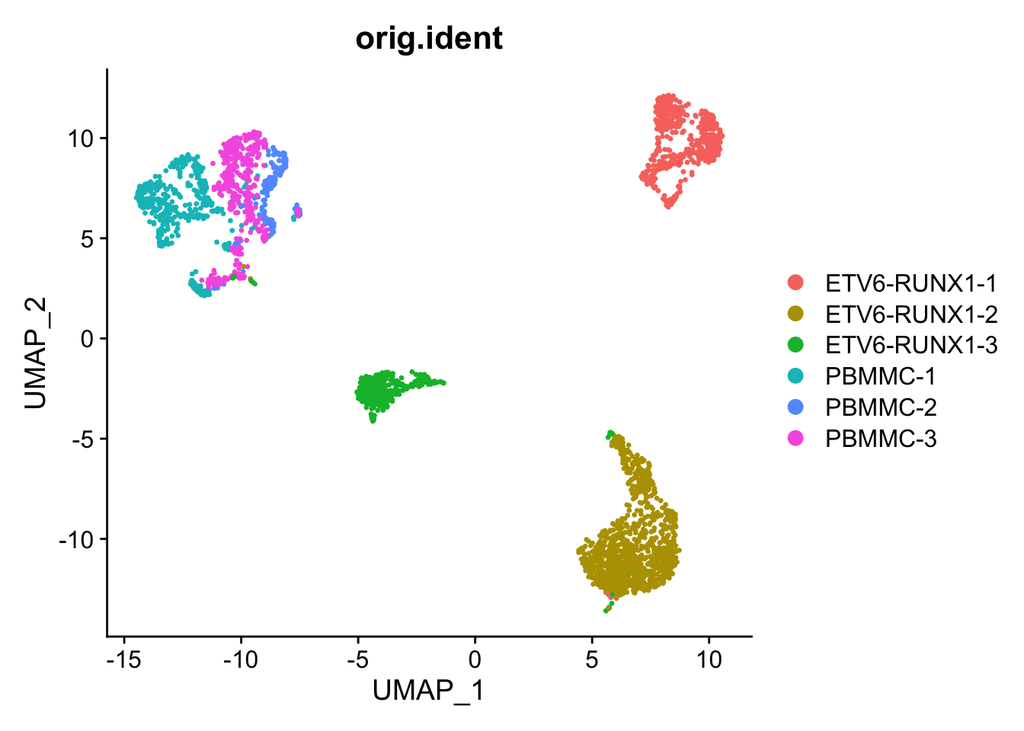

```r
# Load the Seurat object
proB <- readRDS("course_data/proB.rds")

# Plot the samples
DimPlot(proB, group.by = "orig.ident")
```

```r
# How many cells are in each group?
table(proB@meta.data$type)
```

```
##
## ETV6-RUNX1      PBMMC
##       2000       1021
```

### Pseudobulk preparation

Firstly, we make sure that we are using the RNA assay and then I am going to make a new column in the metadata called sample (not essential but I prefer sample to orig.ident).

```r
# Set default assay
Seurat::DefaultAssay(proB) <- "RNA"
# Make sample column
proB$sample <- factor(proB$orig.ident)
# set our identifier as sample
Seurat::Idents(proB) <- proB$sample
```

### Aggregate the counts across cells for each sample

Here we are using the AggregateExpression function to make pseudobulk counts. Note that we are using the raw counts (“counts” slot) because the differential expression methods expect unnormalised counts. Here, we will get Aggregate expression to return a Seurat object so that we can get our metadata easily as well.

```r
proB_summed_seurat <- AggregateExpression(proB,group.by = "sample",assays = "RNA",
                                          slot = "counts",return.seurat = T)
# Extract the counts
summed <- GetAssayData(proB_summed_seurat,assay = "RNA",slot = "counts")
# Convert the counts into a dataframe rather than a sparse matrix
summed <- as.data.frame(as.matrix(summed))
```

### Set up the covariates file

```r
# Extract the metadata as a dataframe from the Seurat object
summed_meta <- proB_summed_seurat[[]]
head(summed_meta)
```

```
##              orig.ident nCount_RNA nFeature_RNA
## ETV6-RUNX1-1  Aggregate    3273723        15170
## ETV6-RUNX1-2  Aggregate    3272997        16113
## ETV6-RUNX1-3  Aggregate    1177522        14518
## PBMMC-1       Aggregate    2458118        15685
## PBMMC-2       Aggregate    1369096        14470
## PBMMC-3       Aggregate    1998447        15107
```

```r
# Make a sample column from the row names
summed_meta$sample <- rownames(summed_meta)

# Add a group variable
summed_meta$group<- c("ETV6_RUNX1", "ETV6_RUNX1","ETV6_RUNX1","PBMMC","PBMMC","PBMMC")
# Make sure that everything is in the right order
head(summed_meta)
```

```
##              orig.ident nCount_RNA nFeature_RNA       sample      group
## ETV6-RUNX1-1  Aggregate    3273723        15170 ETV6-RUNX1-1 ETV6_RUNX1
## ETV6-RUNX1-2  Aggregate    3272997        16113 ETV6-RUNX1-2 ETV6_RUNX1
## ETV6-RUNX1-3  Aggregate    1177522        14518 ETV6-RUNX1-3 ETV6_RUNX1
## PBMMC-1       Aggregate    2458118        15685      PBMMC-1      PBMMC
## PBMMC-2       Aggregate    1369096        14470      PBMMC-2      PBMMC
## PBMMC-3       Aggregate    1998447        15107      PBMMC-3      PBMMC
```

## Differential expression using DESeq2

This is a very superficial example of the main steps using DESeq2. There are further visualisation/quality steps that are worth doing as well. I would highly recommend going through the DESeq2 vignette on the Bioconductor website - http://bioconductor.org/packages/devel/bioc/vignettes/DESeq2/inst/doc/DESeq2.html

```r
library(DESeq2)

# make a DESeq object with our counts and metadata as input. Design is the comparison
# that we are doing (the group variable in this case).
dds <- DESeqDataSetFromMatrix(summed,
                              colData = summed_meta,
                              design = ~ group)
# By default, DESeq2 runs on all genes. You can optionally filter out genes that have
# very low expression. Here we remove genes that don't have a total count of at least 10.
keep <- rowSums(counts(dds)) >= 10
dds <- dds[keep,]

# Run differential expression
dds <- DESeq(dds)
# See the names of the comparisons in the DESeq2 object
resultsNames(dds) # lists the coefficients
```

```
## [1] "Intercept"                 "group_PBMMC_vs_ETV6_RUNX1"
```

### Extract the results for our comparison of interest

```r
# Extract the results from the dds object
res <- results(dds,name = "group_PBMMC_vs_ETV6_RUNX1")
# Convert the results to a dataframe
res_deseq2 <- data.frame(res)

# Inspect the top results
head(res_deseq2)
```

```
##                 baseMean log2FoldChange     lfcSE         stat    pvalue
## FO538757.2    110.903637   -0.185848895 0.3706852 -0.501365788 0.6161137
## AP006222.2     31.201637    0.038857738 0.4816157  0.080682038 0.9356948
## RP4-669L17.10   2.667034   -2.450330131 1.5874118 -1.543600842 0.1226851
## RP11-206L10.9  11.911919   -0.006177167 0.7093924 -0.008707687 0.9930524
## LINC00115       7.967240   -1.058478772 0.8638941 -1.225241405 0.2204843
## FAM41C         15.206333    0.969665597 0.7072966  1.370946124 0.1703918
##                    padj
## FO538757.2    0.8016732
## AP006222.2    0.9707384
## RP4-669L17.10 0.3131130
## RP11-206L10.9 0.9967962
## LINC00115     0.4533124
## FAM41C        0.3865508
```

```r
# The results aren't sorted by p-value so let's do that using the order function
res_deseq2 <- res_deseq2[order(res_deseq2$pvalue),]
# Subset the results to only include those below an adjusted p-value of 0.05
res_deseq2 <- res_deseq2[res_deseq2$padj < 0.05,]
# See how many DEGs there are and show the top 10
dim(res_deseq2)
```

```
## [1] 2884    6
```

```r
head(res_deseq2,10)
```

```
##           baseMean log2FoldChange     lfcSE      stat       pvalue         padj
## RPS4Y2    591.4634      -5.393226 0.3928680 -13.72783 6.917279e-43 9.195831e-39
## DPEP1     216.0785      -6.819585 0.5612840 -12.14997 5.738414e-34 3.814324e-30
## ALOX5     239.1138      -4.123049 0.3548344 -11.61964 3.275005e-31 1.451264e-27
## IGLL1    2661.1635       3.758978 0.3359550  11.18893 4.619726e-29 1.535366e-25
## KIAA0125  137.9428       7.196845 0.6594213  10.91388 9.894105e-28 2.630645e-24
## MDK       611.2813      -4.155693 0.3864768 -10.75276 5.751261e-27 1.274288e-23
## NUSAP1    603.8481       2.896636 0.2752481  10.52373 6.716273e-26 1.275516e-22
## PTP4A3    178.6714      -3.742930 0.3579180 -10.45751 1.353691e-25 2.249496e-22
## GNG11     336.6933      -3.455687 0.3350406 -10.31423 6.076417e-25 8.975542e-22
## TERF2     716.5370      -4.740850 0.4609084 -10.28588 8.159027e-25 1.084661e-21
```

### Comparison to FindMarkers

For comparison, let’s run the differential expression analysis between the same groups using Seurat FindMarkers.

```r
res_FindMarkers <- Seurat::FindMarkers(proB,
                                   ident.1 = "ETV6-RUNX1",
                                   ident.2 = "PBMMC",
                                   group.by = "type")
# Subset the results to only include those below an adjusted p-value of 0.05
res_FindMarkers <- res_FindMarkers[res_FindMarkers$p_val_adj < 0.05,]
# See how many DEGs there are and show the top 10
dim(res_FindMarkers)
```

```
## [1] 1893    5
```

```r
head(res_FindMarkers,10)
```

```
##                  p_val avg_log2FC pct.1 pct.2     p_val_adj
## S100A9    0.000000e+00  -1.913961 0.005 0.601  0.000000e+00
## S100A8    0.000000e+00  -1.924842 0.006 0.598  0.000000e+00
## CD74      0.000000e+00   1.537764 1.000 0.986  0.000000e+00
## HLA-DPA1  0.000000e+00   1.957033 0.967 0.669  0.000000e+00
## SOCS2     0.000000e+00   2.556781 0.906 0.175  0.000000e+00
## IGLL1     0.000000e+00  -2.962544 0.236 0.938  0.000000e+00
## HLA-DRA  2.534734e-306   1.391033 1.000 0.975 5.349048e-302
## RPS4Y2   2.404614e-293   2.895754 0.800 0.046 5.074457e-289
## TERF2    3.757633e-275   3.103549 0.794 0.118 7.929733e-271
## HLA-C    4.605676e-274   1.570351 0.987 0.856 9.719358e-270
```

##### How many common genes are there?

Use the intersect function to find the overlap in genes (the gene names are the rownames of both dataframes).

```r
length(intersect(rownames(res_FindMarkers),rownames(res_deseq2)))
```

```
## [1] 1296
```

#### Notes on comparison

There is substantial overlap between FindMarkers and DESeq2 but there are also several hundred genes that only come up in a single method. Another thing worth noting is the incredibly small p-values in the FindMarkers results compared to DESeq2. This demonstrates the “p-value inflation” observed when running differential expression at the single cell level compared to pseudobulk.

```r
#########################################################################################
#########################################################################################
```

# Appendix

### Differential expression between clusters

```r
# Clusters 0 and 10 both look like T cells, let's compare those clusters
Idents(seu) <- "RNA_snn_res.0.3"

deg_cluster0vs10 <- Seurat::FindMarkers(seu,
                                       ident.1 = 0,
                                       ident.2 = 10,
                                       test.use = "wilcox")
deg_cluster0vs10 <- subset(deg_cluster0vs10, deg_cluster0vs10$p_val_adj<0.05)

# Are the original T-cells clusters different based on CD8/CD4 expression?
# Here I am using %in% instead
deg_cluster0vs10[rownames(deg_cluster0vs10) %in% c("CD4", "CD8A", "CD8B"), ]
```

```
## [1] p_val      avg_log2FC pct.1      pct.2      p_val_adj
## <0 rows> (or 0-length row.names)
```

### Enrichment analysis using MSigDB

Firstly, you need to define your MSigDB list of interest. Here we are using the human “Hallmark” geneset (category H = Hallmark). For further information about the available genesets refer to https://www.gsea-msigdb.org/gsea/msigdb

```r
gmt <- msigdbr::msigdbr(species = "human", category = "H")

# You also need to specify the "universe" which is all of the non-significant genes
# in your analysis (just need to give the rownames of the Seurat object)
cd8_vs_cd4_msigdb <- clusterProfiler::enricher(gene = rownames(deg_cd8_cd4),
                                                universe = rownames(seu),
                                                pAdjustMethod = "BH",
                                                pvalueCutoff  = 0.05,
                                                qvalueCutoff  = 0.05,
                                                TERM2GENE = gmt[,c("gs_name", "gene_symbol")])

head(cd8_vs_cd4_msigdb)
```

```
##                                                                ID
## HALLMARK_TNFA_SIGNALING_VIA_NFKB HALLMARK_TNFA_SIGNALING_VIA_NFKB
## HALLMARK_ALLOGRAFT_REJECTION         HALLMARK_ALLOGRAFT_REJECTION
##                                                       Description GeneRatio
## HALLMARK_TNFA_SIGNALING_VIA_NFKB HALLMARK_TNFA_SIGNALING_VIA_NFKB     11/35
## HALLMARK_ALLOGRAFT_REJECTION         HALLMARK_ALLOGRAFT_REJECTION     10/35
##                                   BgRatio       pvalue     p.adjust
## HALLMARK_TNFA_SIGNALING_VIA_NFKB 193/3709 7.933232e-07 2.062640e-05
## HALLMARK_ALLOGRAFT_REJECTION     175/3709 2.782184e-06 3.616839e-05
##                                        qvalue
## HALLMARK_TNFA_SIGNALING_VIA_NFKB 2.004185e-05
## HALLMARK_ALLOGRAFT_REJECTION     3.514338e-05
##                                                                                        geneID
## HALLMARK_TNFA_SIGNALING_VIA_NFKB CCL5/ID2/CCL4/NR4A2/JUN/LITAF/ZFP36/DUSP2/GPR183/DUSP1/BIRC3
## HALLMARK_ALLOGRAFT_REJECTION              CD8A/CCL5/CD8B/GZMA/KLRD1/CD4/CCL4/TRAT1/SRGN/HLA-A
##                                  Count
## HALLMARK_TNFA_SIGNALING_VIA_NFKB    11
## HALLMARK_ALLOGRAFT_REJECTION        10
```

### Pseudobulk analysis using limma

Feel free to use this example or follow along with the more complex example on the SIB website - https://sib-swiss.github.io/single-cell-training/day3/day3-1_differential_gene_expression.html. You need to filter out lowly expressed genes before running limma. There is a function called filterByExpr that does this automatically but it is on the stringent side. Alternatively you can keep genes that have total counts over a certain value or are above a certain value across a certain number of cells. The main thing is to remove genes that are mostly zeroes across all samples and there is a fine balance between removing noise and preserving biological signal. Filter too harshly, and you can lose lowly expressed (but still potentially informative) genes. Filter too leniently, and the “noise” from extremely lowly expressed genes can make your differential expression model less accurate.

```r
#BiocManager::install(c("limma","edgeR"))
library(limma)
library(edgeR)

# You can filter out genes that don't have at least 10 counts in total
reads_fil <- summed[which(!rowSums(summed)<=10),]
dim(reads_fil)
```

```
## [1] 13650     6
```

```r
# Or filter out the genes that don't have at least a certain number of counts
# in a certain number of samples (at least 5 counts in 3 samples here)
reads_fil <- summed[rowSums(summed >= 5) >= 3, ]
dim(reads_fil)
```

```
## [1] 11533     6
```

#### The filterByExpr method

```r
#keep <- filterByExpr(y, group=summed$group)
#y <- y[keep,]
##see how many genes were kept
#summary(keep)
```

### Set up object and run differential expression

```r
# As in the standard limma analysis generate a DGE object
y <- DGEList(reads_fil)

# create design matrix
## Create the design matrix and include the technology as a covariate:
design <- model.matrix(~0 + group,data = summed_meta)

# Have a look
head(design)
```

```
##              groupETV6_RUNX1 groupPBMMC
## ETV6-RUNX1-1               1          0
## ETV6-RUNX1-2               1          0
## ETV6-RUNX1-3               1          0
## PBMMC-1                    0          1
## PBMMC-2                    0          1
## PBMMC-3                    0          1
```

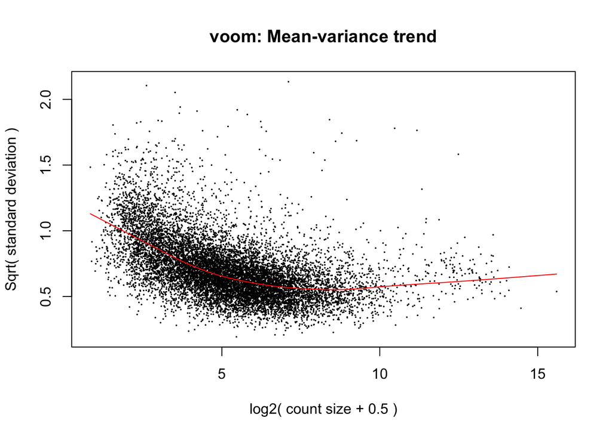

```r
# specify the comparison that you wnat to do
contrast.mat <- limma::makeContrasts(groupETV6_RUNX1 - groupPBMMC,
                                     levels = design)

# normalise for gene length
dge <- edgeR::calcNormFactors(y)

#variance stabilising transformation using voom
vm <- limma::voom(dge, design = design, plot = TRUE)
```

```r
# fit the limma model and run differential expression
fit <- limma::lmFit(vm, design = design)
fit.contrasts <- limma::contrasts.fit(fit, contrast.mat)
fit.contrasts <- limma::eBayes(fit.contrasts)

# Show the top differentially expressed genes:
limma::topTable(fit.contrasts, number = 10, sort.by = "P")
```

```
##             logFC  AveExpr         t      P.Value    adj.P.Val        B
## RPS4Y2   5.378651 6.355433  13.01778 9.469704e-08 0.0005615778 8.309662
## ALOX5    4.147343 5.690506  12.55911 1.345252e-07 0.0005615778 8.016259
## NUSAP1  -2.845096 7.551753 -11.78822 2.491901e-07 0.0005615778 7.560634
## PTP4A3   3.734482 5.457500  11.46865 3.251122e-07 0.0005615778 7.217594
## JUP      2.629376 6.655267  11.35108 3.591138e-07 0.0005615778 7.199076
## SLC27A3  4.032939 4.564557  11.31736 3.695668e-07 0.0005615778 6.892316
## GNG11    3.495117 6.465383  11.28869 3.787140e-07 0.0005615778 7.136213
## GRINA    3.027933 5.602213  11.14942 4.268114e-07 0.0005615778 7.003530
## TGFB1    3.013287 5.591018  11.11842 4.383960e-07 0.0005615778 6.978635
## IGLL1   -3.788694 9.294754 -10.91475 5.235927e-07 0.0005615778 6.830908
```

```
## The default behaviour of split.by has changed.
## Separate violin plots are now plotted side-by-side.
## To restore the old behaviour of a single split violin,
## set split.plot = TRUE.
##
## This message will be shown once per session.
```

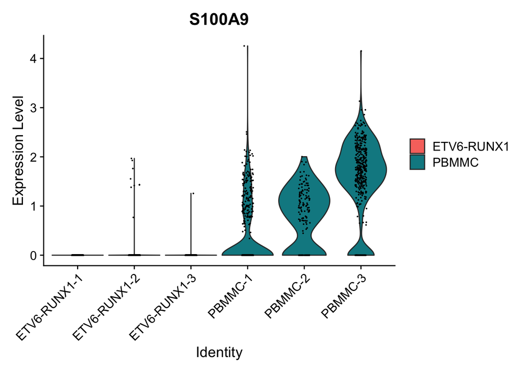

```r
limma_de <- limma::topTable(fit.contrasts, number = Inf, sort.by = "P")
limma_sig <- limma_de[limma_de$adj.P.Val<0.05,]

Seurat::VlnPlot(proB, "S100A9", split.by = "type")
```

```r
# for comparison, let's run the same analysis using Seurat FindMarkers
tum_vs_norm <- Seurat::FindMarkers(proB,
                                   ident.1 = "ETV6-RUNX1",
                                   ident.2 = "PBMMC",
                                   group.by = "type")
tum_vs_norm <- subset(tum_vs_norm, tum_vs_norm$p_val_adj<0.05)

# look at the top 15 genes from each method
head(limma_de,15)
```

```
##             logFC  AveExpr         t      P.Value    adj.P.Val        B
## RPS4Y2   5.378651 6.355433  13.01778 9.469704e-08 0.0005615778 8.309662
## ALOX5    4.147343 5.690506  12.55911 1.345252e-07 0.0005615778 8.016259
## NUSAP1  -2.845096 7.551753 -11.78822 2.491901e-07 0.0005615778 7.560634
## PTP4A3   3.734482 5.457500  11.46865 3.251122e-07 0.0005615778 7.217594
## JUP      2.629376 6.655267  11.35108 3.591138e-07 0.0005615778 7.199076
## SLC27A3  4.032939 4.564557  11.31736 3.695668e-07 0.0005615778 6.892316
## GNG11    3.495117 6.465383  11.28869 3.787140e-07 0.0005615778 7.136213
## GRINA    3.027933 5.602213  11.14942 4.268114e-07 0.0005615778 7.003530
## TGFB1    3.013287 5.591018  11.11842 4.383960e-07 0.0005615778 6.978635
## IGLL1   -3.788694 9.294754 -10.91475 5.235927e-07 0.0005615778 6.830908
## MDK      4.295676 6.955473  10.88893 5.356243e-07 0.0005615778 6.799691
## VAMP5    2.369842 6.885651  10.60325 6.908187e-07 0.0006639343 6.560139
## CBFA2T3  2.992716 5.736094  10.36340 8.592218e-07 0.0007622619 6.339682
## FCGRT    3.779837 6.088715  10.16768 1.029879e-06 0.0008483999 6.161582
## STK32B   4.173461 4.365030  10.03446 1.166995e-06 0.0008520401 5.816978
```

```r
head(tum_vs_norm,15)
```

```
##                  p_val avg_log2FC pct.1 pct.2     p_val_adj
## S100A9    0.000000e+00  -1.913961 0.005 0.601  0.000000e+00
## S100A8    0.000000e+00  -1.924842 0.006 0.598  0.000000e+00
## CD74      0.000000e+00   1.537764 1.000 0.986  0.000000e+00
## HLA-DPA1  0.000000e+00   1.957033 0.967 0.669  0.000000e+00
## SOCS2     0.000000e+00   2.556781 0.906 0.175  0.000000e+00
## IGLL1     0.000000e+00  -2.962544 0.236 0.938  0.000000e+00
## HLA-DRA  2.534734e-306   1.391033 1.000 0.975 5.349048e-302
## RPS4Y2   2.404614e-293   2.895754 0.800 0.046 5.074457e-289
## TERF2    3.757633e-275   3.103549 0.794 0.118 7.929733e-271
## HLA-C    4.605676e-274   1.570351 0.987 0.856 9.719358e-270
## IGKC     2.787744e-267  -2.970943 0.284 0.867 5.882975e-263
## HLA-DPB1 1.604174e-258   1.713583 0.963 0.762 3.385288e-254
## RPL37    4.572335e-254  -1.095580 0.955 0.999 9.648998e-250
## LYZ      2.313547e-252  -1.437385 0.003 0.496 4.882278e-248
## HLA-DRB1 6.629669e-247   1.716703 0.971 0.749 1.399059e-242
```

```r
# what's the overlap between the two methods?
length(intersect(rownames(limma_sig),rownames(tum_vs_norm)))
```

```
## [1] 1252
```

```r
merge_limma_FindMarkers <- merge(tum_vs_norm, limma_de, by="row.names",
                                 all.x=T)
```

#### Plot the fold changes

See if the genes are going in the same direction

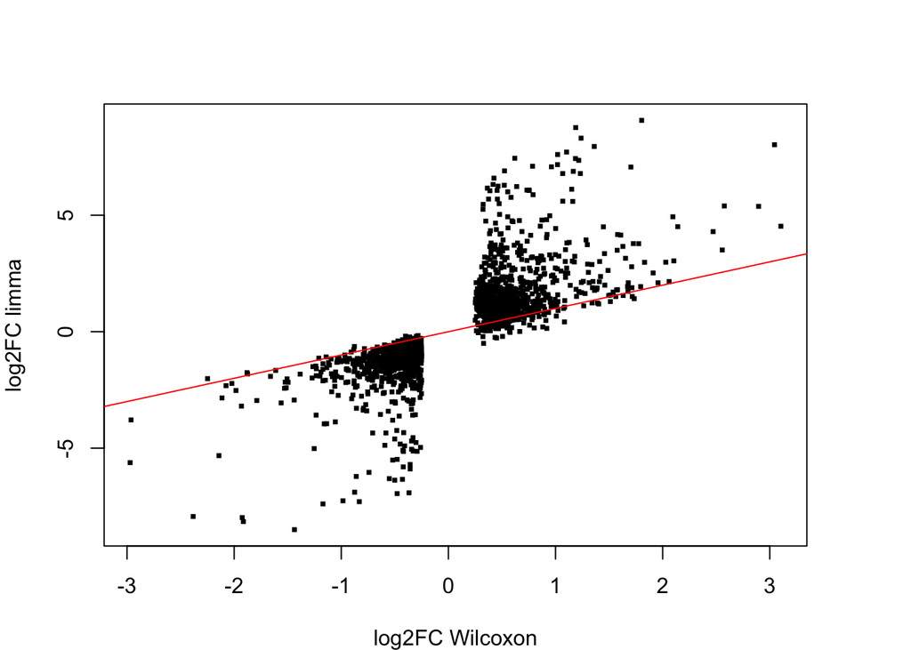

```r
par(mar=c(4,4,4,4))
plot(merge_limma_FindMarkers$avg_log2FC,
     merge_limma_FindMarkers$logFC,
     xlab="log2FC Wilcoxon", ylab="log2FC limma",
     pch=15, cex=0.5)
abline(a=0, b=1, col="red")
```

#### Save the objects

```r
save(limma_de,file="limma_de.RData")
save(tum_vs_norm,file="tum_vs_norm.RData")
```